# Risk Factor Analysis

## Outcome Variable

**Outcome Variable:** wast_rec90d

## Predictor Variables

**Intervention Variable:** birthlen

**Adjustment Set:**

- arm
- sex
- W_mage
- meducyrs
- feducyrs
- hhwealth_quart
- vagbrth
- W_nrooms
- brthmon
- W_parity
- impfloor
- impsan
- safeh20
- delta_W_mage
- delta_meducyrs
- delta_feducyrs
- delta_hhwealth_quart
- delta_vagbrth
- delta_W_nrooms
- delta_brthmon
- delta_W_parity
- delta_impfloor
- delta_impsan
- delta_safeh20

## Stratifying Variables

The analysis was stratified on these variable(s):

- agecat
- studyid
- country

## Data Summary

| agecat | studyid | country | birthlen | wast_rec90d | n_cell | n |
| --- | --- | --- | --- | --- | --- | --- |
| 0-24 months | ki0047075b-MAL-ED | BANGLADESH | >=50 cm | 0 | 4 | 119 |
| 0-24 months | ki0047075b-MAL-ED | BANGLADESH | >=50 cm | 1 | 12 | 119 |
| 0-24 months | ki0047075b-MAL-ED | BANGLADESH | <48 cm | 0 | 25 | 119 |
| 0-24 months | ki0047075b-MAL-ED | BANGLADESH | <48 cm | 1 | 43 | 119 |
| 0-24 months | ki0047075b-MAL-ED | BANGLADESH | [48-50) cm | 0 | 15 | 119 |
| 0-24 months | ki0047075b-MAL-ED | BANGLADESH | [48-50) cm | 1 | 20 | 119 |
| 0-24 months | ki0047075b-MAL-ED | BRAZIL | >=50 cm | 0 | 0 | 22 |
| 0-24 months | ki0047075b-MAL-ED | BRAZIL | >=50 cm | 1 | 6 | 22 |
| 0-24 months | ki0047075b-MAL-ED | BRAZIL | <48 cm | 0 | 3 | 22 |
| 0-24 months | ki0047075b-MAL-ED | BRAZIL | <48 cm | 1 | 6 | 22 |
| 0-24 months | ki0047075b-MAL-ED | BRAZIL | [48-50) cm | 0 | 2 | 22 |
| 0-24 months | ki0047075b-MAL-ED | BRAZIL | [48-50) cm | 1 | 5 | 22 |
| 0-24 months | ki0047075b-MAL-ED | INDIA | >=50 cm | 0 | 3 | 144 |
| 0-24 months | ki0047075b-MAL-ED | INDIA | >=50 cm | 1 | 9 | 144 |
| 0-24 months | ki0047075b-MAL-ED | INDIA | <48 cm | 0 | 35 | 144 |
| 0-24 months | ki0047075b-MAL-ED | INDIA | <48 cm | 1 | 45 | 144 |
| 0-24 months | ki0047075b-MAL-ED | INDIA | [48-50) cm | 0 | 19 | 144 |
| 0-24 months | ki0047075b-MAL-ED | INDIA | [48-50) cm | 1 | 33 | 144 |
| 0-24 months | ki0047075b-MAL-ED | NEPAL | >=50 cm | 0 | 4 | 72 |
| 0-24 months | ki0047075b-MAL-ED | NEPAL | >=50 cm | 1 | 8 | 72 |
| 0-24 months | ki0047075b-MAL-ED | NEPAL | <48 cm | 0 | 8 | 72 |
| 0-24 months | ki0047075b-MAL-ED | NEPAL | <48 cm | 1 | 38 | 72 |
| 0-24 months | ki0047075b-MAL-ED | NEPAL | [48-50) cm | 0 | 1 | 72 |
| 0-24 months | ki0047075b-MAL-ED | NEPAL | [48-50) cm | 1 | 13 | 72 |
| 0-24 months | ki0047075b-MAL-ED | PERU | >=50 cm | 0 | 0 | 34 |
| 0-24 months | ki0047075b-MAL-ED | PERU | >=50 cm | 1 | 4 | 34 |
| 0-24 months | ki0047075b-MAL-ED | PERU | <48 cm | 0 | 5 | 34 |
| 0-24 months | ki0047075b-MAL-ED | PERU | <48 cm | 1 | 17 | 34 |
| 0-24 months | ki0047075b-MAL-ED | PERU | [48-50) cm | 0 | 1 | 34 |
| 0-24 months | ki0047075b-MAL-ED | PERU | [48-50) cm | 1 | 7 | 34 |

[output cut: 444 more lines]

The following strata were considered:

- agecat: 0-24 months, studyid: ki0047075b-MAL-ED, country: BANGLADESH
- agecat: 0-24 months, studyid: ki0047075b-MAL-ED, country: BRAZIL
- agecat: 0-24 months, studyid: ki0047075b-MAL-ED, country: INDIA
- agecat: 0-24 months, studyid: ki0047075b-MAL-ED, country: NEPAL
- agecat: 0-24 months, studyid: ki0047075b-MAL-ED, country: PERU
- agecat: 0-24 months, studyid: ki0047075b-MAL-ED, country: SOUTH AFRICA
- agecat: 0-24 months, studyid: ki0047075b-MAL-ED, country: TANZANIA, UNITED REPUBLIC OF
- agecat: 0-24 months, studyid: ki1000108-CMC-V-BCS-2002, country: INDIA
- agecat: 0-24 months, studyid: ki1000108-IRC, country: INDIA
- agecat: 0-24 months, studyid: ki1000109-EE, country: PAKISTAN
- agecat: 0-24 months, studyid: ki1000109-ResPak, country: PAKISTAN
- agecat: 0-24 months, studyid: ki1000304b-SAS-CompFeed, country: INDIA
- agecat: 0-24 months, studyid: ki1017093-NIH-Birth, country: BANGLADESH
- agecat: 0-24 months, studyid: ki1017093b-PROVIDE, country: BANGLADESH
- agecat: 0-24 months, studyid: ki1017093c-NIH-Crypto, country: BANGLADESH
- agecat: 0-24 months, studyid: ki1101329-Keneba, country: GAMBIA
- agecat: 0-24 months, studyid: ki1114097-CMIN, country: BANGLADESH
- agecat: 0-24 months, studyid: ki1114097-CMIN, country: BRAZIL
- agecat: 0-24 months, studyid: ki1114097-CMIN, country: GUINEA-BISSAU
- agecat: 0-24 months, studyid: ki1114097-CMIN, country: PERU
- agecat: 0-24 months, studyid: ki1119695-PROBIT, country: BELARUS
- agecat: 0-24 months, studyid: ki1126311-ZVITAMBO, country: ZIMBABWE
- agecat: 0-24 months, studyid: ki1135781-COHORTS, country: GUATEMALA
- agecat: 0-24 months, studyid: ki1135781-COHORTS, country: INDIA
- agecat: 0-24 months, studyid: ki1135781-COHORTS, country: PHILIPPINES
- agecat: 0-24 months, studyid: kiGH5241-JiVitA-3, country: BANGLADESH
- agecat: 0-24 months, studyid: kiGH5241-JiVitA-4, country: BANGLADESH
- agecat: 0-6 months, studyid: ki0047075b-MAL-ED, country: BANGLADESH
- agecat: 0-6 months, studyid: ki0047075b-MAL-ED, country: BRAZIL
- agecat: 0-6 months, studyid: ki0047075b-MAL-ED, country: INDIA
- agecat: 0-6 months, studyid: ki0047075b-MAL-ED, country: NEPAL
- agecat: 0-6 months, studyid: ki0047075b-MAL-ED, country: PERU
- agecat: 0-6 months, studyid: ki0047075b-MAL-ED, country: SOUTH AFRICA
- agecat: 0-6 months, studyid: ki0047075b-MAL-ED, country: TANZANIA, UNITED REPUBLIC OF
- agecat: 0-6 months, studyid: ki1000108-CMC-V-BCS-2002, country: INDIA
- agecat: 0-6 months, studyid: ki1000108-IRC, country: INDIA
- agecat: 0-6 months, studyid: ki1000109-EE, country: PAKISTAN
- agecat: 0-6 months, studyid: ki1000109-ResPak, country: PAKISTAN
- agecat: 0-6 months, studyid: ki1000304b-SAS-CompFeed, country: INDIA
- agecat: 0-6 months, studyid: ki1017093-NIH-Birth, country: BANGLADESH
- agecat: 0-6 months, studyid: ki1017093b-PROVIDE, country: BANGLADESH
- agecat: 0-6 months, studyid: ki1017093c-NIH-Crypto, country: BANGLADESH
- agecat: 0-6 months, studyid: ki1101329-Keneba, country: GAMBIA
- agecat: 0-6 months, studyid: ki1114097-CMIN, country: BANGLADESH
- agecat: 0-6 months, studyid: ki1114097-CMIN, country: BRAZIL
- agecat: 0-6 months, studyid: ki1114097-CMIN, country: GUINEA-BISSAU
- agecat: 0-6 months, studyid: ki1114097-CMIN, country: PERU
- agecat: 0-6 months, studyid: ki1119695-PROBIT, country: BELARUS
- agecat: 0-6 months, studyid: ki1126311-ZVITAMBO, country: ZIMBABWE
- agecat: 0-6 months, studyid: ki1135781-COHORTS, country: GUATEMALA
- agecat: 0-6 months, studyid: ki1135781-COHORTS, country: INDIA
- agecat: 0-6 months, studyid: ki1135781-COHORTS, country: PHILIPPINES
- agecat: 0-6 months, studyid: kiGH5241-JiVitA-3, country: BANGLADESH
- agecat: 0-6 months, studyid: kiGH5241-JiVitA-4, country: BANGLADESH
- agecat: 6-24 months, studyid: ki0047075b-MAL-ED, country: BANGLADESH
- agecat: 6-24 months, studyid: ki0047075b-MAL-ED, country: BRAZIL
- agecat: 6-24 months, studyid: ki0047075b-MAL-ED, country: INDIA
- agecat: 6-24 months, studyid: ki0047075b-MAL-ED, country: NEPAL
- agecat: 6-24 months, studyid: ki0047075b-MAL-ED, country: PERU
- agecat: 6-24 months, studyid: ki0047075b-MAL-ED, country: SOUTH AFRICA
- agecat: 6-24 months, studyid: ki0047075b-MAL-ED, country: TANZANIA, UNITED REPUBLIC OF
- agecat: 6-24 months, studyid: ki1000108-CMC-V-BCS-2002, country: INDIA
- agecat: 6-24 months, studyid: ki1000108-IRC, country: INDIA
- agecat: 6-24 months, studyid: ki1000109-EE, country: PAKISTAN
- agecat: 6-24 months, studyid: ki1000109-ResPak, country: PAKISTAN
- agecat: 6-24 months, studyid: ki1000304b-SAS-CompFeed, country: INDIA
- agecat: 6-24 months, studyid: ki1017093-NIH-Birth, country: BANGLADESH
- agecat: 6-24 months, studyid: ki1017093b-PROVIDE, country: BANGLADESH
- agecat: 6-24 months, studyid: ki1017093c-NIH-Crypto, country: BANGLADESH
- agecat: 6-24 months, studyid: ki1101329-Keneba, country: GAMBIA
- agecat: 6-24 months, studyid: ki1114097-CMIN, country: BRAZIL
- agecat: 6-24 months, studyid: ki1114097-CMIN, country: PERU
- agecat: 6-24 months, studyid: ki1119695-PROBIT, country: BELARUS
- agecat: 6-24 months, studyid: ki1126311-ZVITAMBO, country: ZIMBABWE
- agecat: 6-24 months, studyid: ki1135781-COHORTS, country: GUATEMALA
- agecat: 6-24 months, studyid: ki1135781-COHORTS, country: INDIA
- agecat: 6-24 months, studyid: ki1135781-COHORTS, country: PHILIPPINES
- agecat: 6-24 months, studyid: kiGH5241-JiVitA-3, country: BANGLADESH
- agecat: 6-24 months, studyid: kiGH5241-JiVitA-4, country: BANGLADESH

### Dropped Strata

Some strata were dropped due to rare outcomes:

- agecat: 0-24 months, studyid: ki0047075b-MAL-ED, country: BANGLADESH
- agecat: 0-24 months, studyid: ki0047075b-MAL-ED, country: BRAZIL
- agecat: 0-24 months, studyid: ki0047075b-MAL-ED, country: INDIA
- agecat: 0-24 months, studyid: ki0047075b-MAL-ED, country: NEPAL
- agecat: 0-24 months, studyid: ki0047075b-MAL-ED, country: PERU
- agecat: 0-24 months, studyid: ki0047075b-MAL-ED, country: SOUTH AFRICA
- agecat: 0-24 months, studyid: ki0047075b-MAL-ED, country: TANZANIA, UNITED REPUBLIC OF
- agecat: 0-24 months, studyid: ki1000108-CMC-V-BCS-2002, country: INDIA
- agecat: 0-24 months, studyid: ki1000109-ResPak, country: PAKISTAN
- agecat: 0-24 months, studyid: ki1114097-CMIN, country: BANGLADESH
- agecat: 0-24 months, studyid: ki1114097-CMIN, country: BRAZIL
- agecat: 0-24 months, studyid: ki1114097-CMIN, country: GUINEA-BISSAU
- agecat: 0-24 months, studyid: ki1114097-CMIN, country: PERU
- agecat: 0-6 months, studyid: ki0047075b-MAL-ED, country: BANGLADESH
- agecat: 0-6 months, studyid: ki0047075b-MAL-ED, country: BRAZIL
- agecat: 0-6 months, studyid: ki0047075b-MAL-ED, country: INDIA
- agecat: 0-6 months, studyid: ki0047075b-MAL-ED, country: NEPAL
- agecat: 0-6 months, studyid: ki0047075b-MAL-ED, country: PERU
- agecat: 0-6 months, studyid: ki0047075b-MAL-ED, country: SOUTH AFRICA
- agecat: 0-6 months, studyid: ki0047075b-MAL-ED, country: TANZANIA, UNITED REPUBLIC OF
- agecat: 0-6 months, studyid: ki1000108-CMC-V-BCS-2002, country: INDIA
- agecat: 0-6 months, studyid: ki1000109-EE, country: PAKISTAN
- agecat: 0-6 months, studyid: ki1000109-ResPak, country: PAKISTAN
- agecat: 0-6 months, studyid: ki1017093-NIH-Birth, country: BANGLADESH
- agecat: 0-6 months, studyid: ki1017093c-NIH-Crypto, country: BANGLADESH
- agecat: 0-6 months, studyid: ki1114097-CMIN, country: BANGLADESH
- agecat: 0-6 months, studyid: ki1114097-CMIN, country: BRAZIL
- agecat: 0-6 months, studyid: ki1114097-CMIN, country: GUINEA-BISSAU
- agecat: 0-6 months, studyid: ki1114097-CMIN, country: PERU
- agecat: 6-24 months, studyid: ki0047075b-MAL-ED, country: BANGLADESH
- agecat: 6-24 months, studyid: ki0047075b-MAL-ED, country: BRAZIL
- agecat: 6-24 months, studyid: ki0047075b-MAL-ED, country: INDIA
- agecat: 6-24 months, studyid: ki0047075b-MAL-ED, country: NEPAL
- agecat: 6-24 months, studyid: ki0047075b-MAL-ED, country: PERU
- agecat: 6-24 months, studyid: ki0047075b-MAL-ED, country: SOUTH AFRICA
- agecat: 6-24 months, studyid: ki0047075b-MAL-ED, country: TANZANIA, UNITED REPUBLIC OF
- agecat: 6-24 months, studyid: ki1000108-CMC-V-BCS-2002, country: INDIA
- agecat: 6-24 months, studyid: ki1000109-EE, country: PAKISTAN
- agecat: 6-24 months, studyid: ki1000109-ResPak, country: PAKISTAN
- agecat: 6-24 months, studyid: ki1017093-NIH-Birth, country: BANGLADESH
- agecat: 6-24 months, studyid: ki1017093b-PROVIDE, country: BANGLADESH
- agecat: 6-24 months, studyid: ki1017093c-NIH-Crypto, country: BANGLADESH
- agecat: 6-24 months, studyid: ki1114097-CMIN, country: BRAZIL
- agecat: 6-24 months, studyid: ki1114097-CMIN, country: PERU
- agecat: 6-24 months, studyid: ki1119695-PROBIT, country: BELARUS
- agecat: 6-24 months, studyid: ki1135781-COHORTS, country: GUATEMALA
- agecat: 6-24 months, studyid: ki1135781-COHORTS, country: INDIA
- agecat: 6-24 months, studyid: kiGH5241-JiVitA-3, country: BANGLADESH

## Methods Detail

We’re interested in the causal parameters $E[Y_a]$ for all values of $a \in \mathcal{A}$. These parameters represent the mean outcome if, possibly contrary to fact, we intervened to set all units to have $A=a$. Under the randomization and positivity assumptions, these are identified by the statistical parameters $\psi_a=E_W[E_{Y|A,W}(Y|A=a,W)]$. In addition, we’re interested in the mean of $Y$, $E[Y]$ under no intervention (the observed mean). We will estimate these parameters by using SuperLearner to fit the relevant likelihood factors – $E_{Y|A,W}(Y|A=a,W)$ and $p(A=a|W)$, and then updating our likelihood fit using a joint TMLE.

For unadjusted analyses ($W=\{\}$), initial likelihoods were estimated using Lrnr_glm to estimate the simple $E(Y|A)$ and Lrnr_mean to estimate $p(A)$. For adjusted analyses, a small library containing Lrnr_glmnet, Lrnr_xgboost, and Lrnr_mean was used.

Having estimated these parameters, we will then use the delta method to estimate relative risks and attributable risks relative to a prespecified baseline level of $A$.

# Results Detail

## Results Plots

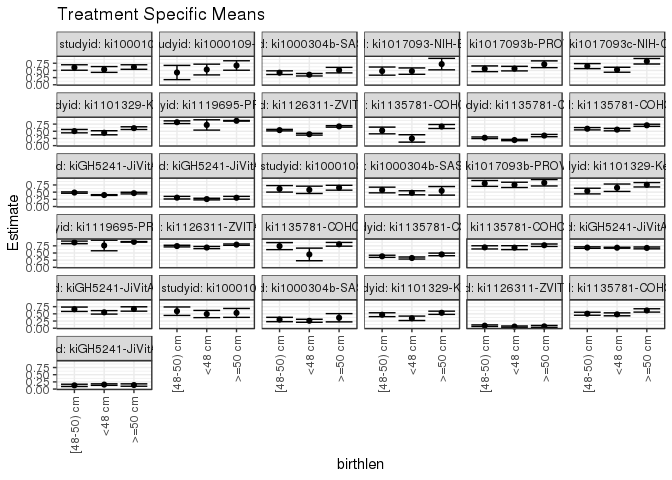

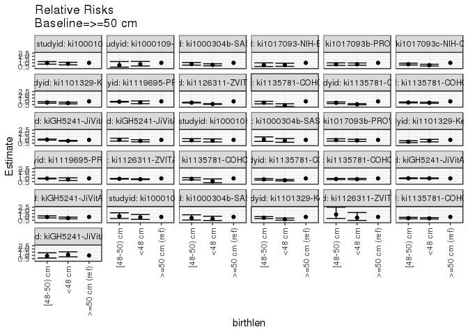

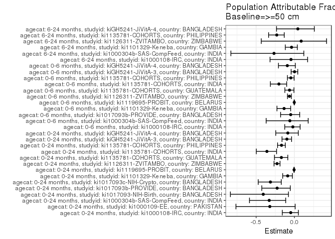

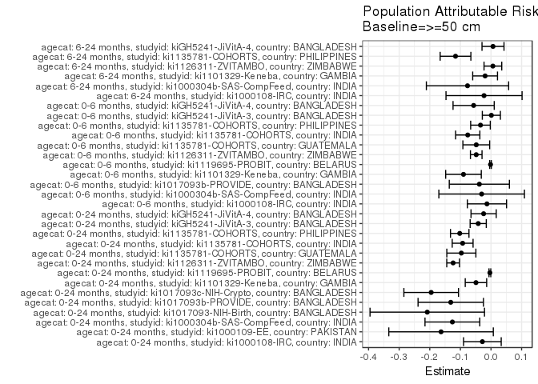

## Results Table

### Parameter: TSM

| agecat | studyid | country | intervention_level | baseline_level | estimate | ci_lower | ci_upper |
| --- | --- | --- | --- | --- | --- | --- | --- |
| 0-24 months | ki1000108-IRC | INDIA | >=50 cm | NA | 0.6172840 | 0.5377766 | 0.6967913 |
| 0-24 months | ki1000108-IRC | INDIA | <48 cm | NA | 0.5327103 | 0.4316629 | 0.6337577 |
| 0-24 months | ki1000108-IRC | INDIA | [48-50) cm | NA | 0.6016949 | 0.5069499 | 0.6964399 |
| 0-24 months | ki1000109-EE | PAKISTAN | >=50 cm | NA | 0.6710748 | 0.5060143 | 0.8361353 |
| 0-24 months | ki1000109-EE | PAKISTAN | <48 cm | NA | 0.5307420 | 0.3442444 | 0.7172396 |
| 0-24 months | ki1000109-EE | PAKISTAN | [48-50) cm | NA | 0.4266446 | 0.1789794 | 0.6743099 |
| 0-24 months | ki1000304b-SAS-CompFeed | INDIA | >=50 cm | NA | 0.5093181 | 0.4132055 | 0.6054306 |
| 0-24 months | ki1000304b-SAS-CompFeed | INDIA | <48 cm | NA | 0.3500034 | 0.3068887 | 0.3931181 |
| 0-24 months | ki1000304b-SAS-CompFeed | INDIA | [48-50) cm | NA | 0.4211101 | 0.3571292 | 0.4850910 |
| 0-24 months | ki1017093-NIH-Birth | BANGLADESH | >=50 cm | NA | 0.7200000 | 0.5200875 | 0.9199125 |
| 0-24 months | ki1017093-NIH-Birth | BANGLADESH | <48 cm | NA | 0.4756098 | 0.3649515 | 0.5862680 |
| 0-24 months | ki1017093-NIH-Birth | BANGLADESH | [48-50) cm | NA | 0.4761905 | 0.3342656 | 0.6181153 |
| 0-24 months | ki1017093b-PROVIDE | BANGLADESH | >=50 cm | NA | 0.7145443 | 0.5963967 | 0.8326920 |
| 0-24 months | ki1017093b-PROVIDE | BANGLADESH | <48 cm | NA | 0.5628613 | 0.4838493 | 0.6418734 |
| 0-24 months | ki1017093b-PROVIDE | BANGLADESH | [48-50) cm | NA | 0.5566307 | 0.4568958 | 0.6563656 |
| 0-24 months | ki1017093c-NIH-Crypto | BANGLADESH | >=50 cm | NA | 0.8191896 | 0.7235622 | 0.9148170 |
| 0-24 months | ki1017093c-NIH-Crypto | BANGLADESH | <48 cm | NA | 0.5227276 | 0.4359505 | 0.6095047 |
| 0-24 months | ki1017093c-NIH-Crypto | BANGLADESH | [48-50) cm | NA | 0.6501834 | 0.5629891 | 0.7373777 |
| 0-24 months | ki1101329-Keneba | GAMBIA | >=50 cm | NA | 0.6084358 | 0.5613314 | 0.6555402 |
| 0-24 months | ki1101329-Keneba | GAMBIA | <48 cm | NA | 0.4481434 | 0.3771702 | 0.5191167 |
| 0-24 months | ki1101329-Keneba | GAMBIA | [48-50) cm | NA | 0.5046038 | 0.4459064 | 0.5633011 |
| 0-24 months | ki1119695-PROBIT | BELARUS | >=50 cm | NA | 0.8648064 | 0.8544839 | 0.8751288 |
| 0-24 months | ki1119695-PROBIT | BELARUS | <48 cm | NA | 0.7200000 | 0.5401187 | 0.8998813 |
| 0-24 months | ki1119695-PROBIT | BELARUS | [48-50) cm | NA | 0.8152610 | 0.7681659 | 0.8623562 |
| 0-24 months | ki1126311-ZVITAMBO | ZIMBABWE | >=50 cm | NA | 0.6697320 | 0.6441701 | 0.6952938 |
| 0-24 months | ki1126311-ZVITAMBO | ZIMBABWE | <48 cm | NA | 0.3974935 | 0.3668198 | 0.4281673 |
| 0-24 months | ki1126311-ZVITAMBO | ZIMBABWE | [48-50) cm | NA | 0.5403760 | 0.5140030 | 0.5667490 |
| 0-24 months | ki1135781-COHORTS | GUATEMALA | >=50 cm | NA | 0.6663424 | 0.5968256 | 0.7358592 |
| 0-24 months | ki1135781-COHORTS | GUATEMALA | <48 cm | NA | 0.2508280 | 0.1217567 | 0.3798993 |
| 0-24 months | ki1135781-COHORTS | GUATEMALA | [48-50) cm | NA | 0.5272678 | 0.4100307 | 0.6445049 |

[output cut: 63 more lines]

### Parameter: E(Y)

| agecat | studyid | country | intervention_level | baseline_level | estimate | ci_lower | ci_upper |
| --- | --- | --- | --- | --- | --- | --- | --- |
| 0-24 months | ki1000108-IRC | INDIA | NA | NA | 0.5891473 | 0.5364145 | 0.6418800 |
| 0-24 months | ki1000109-EE | PAKISTAN | NA | NA | 0.5079365 | 0.3724516 | 0.6434214 |
| 0-24 months | ki1000304b-SAS-CompFeed | INDIA | NA | NA | 0.3831891 | 0.3479331 | 0.4184451 |
| 0-24 months | ki1017093-NIH-Birth | BANGLADESH | NA | NA | 0.5117647 | 0.4302715 | 0.5932579 |
| 0-24 months | ki1017093b-PROVIDE | BANGLADESH | NA | NA | 0.5830619 | 0.5262762 | 0.6398476 |
| 0-24 months | ki1017093c-NIH-Crypto | BANGLADESH | NA | NA | 0.6237942 | 0.5698223 | 0.6777662 |
| 0-24 months | ki1101329-Keneba | GAMBIA | NA | NA | 0.5593036 | 0.5241177 | 0.5944895 |
| 0-24 months | ki1119695-PROBIT | BELARUS | NA | NA | 0.8612051 | 0.8511051 | 0.8713052 |
| 0-24 months | ki1126311-ZVITAMBO | ZIMBABWE | NA | NA | 0.5459916 | 0.5294878 | 0.5624953 |
| 0-24 months | ki1135781-COHORTS | GUATEMALA | NA | NA | 0.5694915 | 0.5120418 | 0.6269413 |
| 0-24 months | ki1135781-COHORTS | INDIA | NA | NA | 0.2579095 | 0.2406335 | 0.2751855 |
| 0-24 months | ki1135781-COHORTS | PHILIPPINES | NA | NA | 0.6067616 | 0.5822457 | 0.6312775 |
| 0-24 months | kiGH5241-JiVitA-3 | BANGLADESH | NA | NA | 0.4249094 | 0.4136873 | 0.4361315 |
| 0-24 months | kiGH5241-JiVitA-4 | BANGLADESH | NA | NA | 0.2796610 | 0.2580570 | 0.3012650 |
| 0-6 months | ki1000108-IRC | INDIA | NA | NA | 0.6398305 | 0.5770134 | 0.7026476 |
| 0-6 months | ki1000304b-SAS-CompFeed | INDIA | NA | NA | 0.5147059 | 0.4610948 | 0.5683169 |
| 0-6 months | ki1017093b-PROVIDE | BANGLADESH | NA | NA | 0.7880435 | 0.7295878 | 0.8464992 |
| 0-6 months | ki1101329-Keneba | GAMBIA | NA | NA | 0.6666667 | 0.6089363 | 0.7243970 |
| 0-6 months | ki1119695-PROBIT | BELARUS | NA | NA | 0.8855266 | 0.8758983 | 0.8951550 |
| 0-6 months | ki1126311-ZVITAMBO | ZIMBABWE | NA | NA | 0.7430390 | 0.7259692 | 0.7601088 |
| 0-6 months | ki1135781-COHORTS | GUATEMALA | NA | NA | 0.7547170 | 0.6968087 | 0.8126253 |
| 0-6 months | ki1135781-COHORTS | INDIA | NA | NA | 0.3750728 | 0.3521661 | 0.3979795 |
| 0-6 months | ki1135781-COHORTS | PHILIPPINES | NA | NA | 0.7363515 | 0.7047428 | 0.7679603 |
| 0-6 months | kiGH5241-JiVitA-3 | BANGLADESH | NA | NA | 0.6779443 | 0.6645427 | 0.6913460 |
| 0-6 months | kiGH5241-JiVitA-4 | BANGLADESH | NA | NA | 0.6130952 | 0.5705324 | 0.6556580 |
| 6-24 months | ki1000108-IRC | INDIA | NA | NA | 0.5099338 | 0.4248374 | 0.5950302 |
| 6-24 months | ki1000304b-SAS-CompFeed | INDIA | NA | NA | 0.2878465 | 0.2457514 | 0.3299415 |
| 6-24 months | ki1101329-Keneba | GAMBIA | NA | NA | 0.5180723 | 0.4773341 | 0.5588105 |
| 6-24 months | ki1126311-ZVITAMBO | ZIMBABWE | NA | NA | 0.0701249 | 0.0547060 | 0.0855437 |
| 6-24 months | ki1135781-COHORTS | PHILIPPINES | NA | NA | 0.5026738 | 0.4688037 | 0.5365439 |
| 6-24 months | kiGH5241-JiVitA-4 | BANGLADESH | NA | NA | 0.1469194 | 0.1276367 | 0.1662021 |

### Parameter: RR

| agecat | studyid | country | intervention_level | baseline_level | estimate | ci_lower | ci_upper |
| --- | --- | --- | --- | --- | --- | --- | --- |
| 0-24 months | ki1000108-IRC | INDIA | >=50 cm | >=50 cm | 1.0000000 | 1.0000000 | 1.0000000 |
| 0-24 months | ki1000108-IRC | INDIA | <48 cm | >=50 cm | 0.8629907 | 0.6863366 | 1.0851131 |
| 0-24 months | ki1000108-IRC | INDIA | [48-50) cm | >=50 cm | 0.9747458 | 0.7951915 | 1.1948434 |
| 0-24 months | ki1000109-EE | PAKISTAN | >=50 cm | >=50 cm | 1.0000000 | 1.0000000 | 1.0000000 |
| 0-24 months | ki1000109-EE | PAKISTAN | <48 cm | >=50 cm | 0.7908835 | 0.5159881 | 1.2122310 |
| 0-24 months | ki1000109-EE | PAKISTAN | [48-50) cm | >=50 cm | 0.6357632 | 0.3366489 | 1.2006422 |
| 0-24 months | ki1000304b-SAS-CompFeed | INDIA | >=50 cm | >=50 cm | 1.0000000 | 1.0000000 | 1.0000000 |
| 0-24 months | ki1000304b-SAS-CompFeed | INDIA | <48 cm | >=50 cm | 0.6872001 | 0.5489833 | 0.8602155 |
| 0-24 months | ki1000304b-SAS-CompFeed | INDIA | [48-50) cm | >=50 cm | 0.8268117 | 0.6491889 | 1.0530335 |
| 0-24 months | ki1017093-NIH-Birth | BANGLADESH | >=50 cm | >=50 cm | 1.0000000 | 1.0000000 | 1.0000000 |
| 0-24 months | ki1017093-NIH-Birth | BANGLADESH | <48 cm | >=50 cm | 0.6605691 | 0.4598630 | 0.9488729 |
| 0-24 months | ki1017093-NIH-Birth | BANGLADESH | [48-50) cm | >=50 cm | 0.6613757 | 0.4401309 | 0.9938357 |
| 0-24 months | ki1017093b-PROVIDE | BANGLADESH | >=50 cm | >=50 cm | 1.0000000 | 1.0000000 | 1.0000000 |
| 0-24 months | ki1017093b-PROVIDE | BANGLADESH | <48 cm | >=50 cm | 0.7877206 | 0.6341188 | 0.9785293 |
| 0-24 months | ki1017093b-PROVIDE | BANGLADESH | [48-50) cm | >=50 cm | 0.7790010 | 0.6103467 | 0.9942587 |
| 0-24 months | ki1017093c-NIH-Crypto | BANGLADESH | >=50 cm | >=50 cm | 1.0000000 | 1.0000000 | 1.0000000 |
| 0-24 months | ki1017093c-NIH-Crypto | BANGLADESH | <48 cm | >=50 cm | 0.6381033 | 0.5204626 | 0.7823344 |
| 0-24 months | ki1017093c-NIH-Crypto | BANGLADESH | [48-50) cm | >=50 cm | 0.7936910 | 0.6644832 | 0.9480231 |
| 0-24 months | ki1101329-Keneba | GAMBIA | >=50 cm | >=50 cm | 1.0000000 | 1.0000000 | 1.0000000 |
| 0-24 months | ki1101329-Keneba | GAMBIA | <48 cm | >=50 cm | 0.7365500 | 0.6177895 | 0.8781404 |
| 0-24 months | ki1101329-Keneba | GAMBIA | [48-50) cm | >=50 cm | 0.8293459 | 0.7217364 | 0.9529997 |
| 0-24 months | ki1119695-PROBIT | BELARUS | >=50 cm | >=50 cm | 1.0000000 | 1.0000000 | 1.0000000 |
| 0-24 months | ki1119695-PROBIT | BELARUS | <48 cm | >=50 cm | 0.8325563 | 0.6483177 | 1.0691518 |
| 0-24 months | ki1119695-PROBIT | BELARUS | [48-50) cm | >=50 cm | 0.9427094 | 0.8887094 | 0.9999905 |
| 0-24 months | ki1126311-ZVITAMBO | ZIMBABWE | >=50 cm | >=50 cm | 1.0000000 | 1.0000000 | 1.0000000 |
| 0-24 months | ki1126311-ZVITAMBO | ZIMBABWE | <48 cm | >=50 cm | 0.5935113 | 0.5445985 | 0.6468173 |
| 0-24 months | ki1126311-ZVITAMBO | ZIMBABWE | [48-50) cm | >=50 cm | 0.8068541 | 0.7584708 | 0.8583239 |
| 0-24 months | ki1135781-COHORTS | GUATEMALA | >=50 cm | >=50 cm | 1.0000000 | 1.0000000 | 1.0000000 |
| 0-24 months | ki1135781-COHORTS | GUATEMALA | <48 cm | >=50 cm | 0.3764251 | 0.2226697 | 0.6363498 |
| 0-24 months | ki1135781-COHORTS | GUATEMALA | [48-50) cm | >=50 cm | 0.7912866 | 0.6189116 | 1.0116703 |

[output cut: 63 more lines]

### Parameter: PAR

| agecat | studyid | country | intervention_level | baseline_level | estimate | ci_lower | ci_upper |
| --- | --- | --- | --- | --- | --- | --- | --- |
| 0-24 months | ki1000108-IRC | INDIA | >=50 cm | NA | -0.0281367 | -0.0896721 | 0.0333988 |
| 0-24 months | ki1000109-EE | PAKISTAN | >=50 cm | NA | -0.1631383 | -0.3338503 | 0.0075737 |
| 0-24 months | ki1000304b-SAS-CompFeed | INDIA | >=50 cm | NA | -0.1261289 | -0.2155994 | -0.0366585 |
| 0-24 months | ki1017093-NIH-Birth | BANGLADESH | >=50 cm | NA | -0.2082353 | -0.3952402 | -0.0212304 |
| 0-24 months | ki1017093b-PROVIDE | BANGLADESH | >=50 cm | NA | -0.1314824 | -0.2382813 | -0.0246836 |
| 0-24 months | ki1017093c-NIH-Crypto | BANGLADESH | >=50 cm | NA | -0.1953954 | -0.2846056 | -0.1061852 |
| 0-24 months | ki1101329-Keneba | GAMBIA | >=50 cm | NA | -0.0491323 | -0.0841198 | -0.0141447 |
| 0-24 months | ki1119695-PROBIT | BELARUS | >=50 cm | NA | -0.0036012 | -0.0065370 | -0.0006654 |
| 0-24 months | ki1126311-ZVITAMBO | ZIMBABWE | >=50 cm | NA | -0.1237404 | -0.1445071 | -0.1029737 |
| 0-24 months | ki1135781-COHORTS | GUATEMALA | >=50 cm | NA | -0.0968509 | -0.1443310 | -0.0493708 |
| 0-24 months | ki1135781-COHORTS | INDIA | >=50 cm | NA | -0.0926184 | -0.1266969 | -0.0585400 |
| 0-24 months | ki1135781-COHORTS | PHILIPPINES | >=50 cm | NA | -0.1021705 | -0.1323575 | -0.0719836 |
| 0-24 months | kiGH5241-JiVitA-3 | BANGLADESH | >=50 cm | NA | -0.0417482 | -0.0681345 | -0.0153619 |
| 0-24 months | kiGH5241-JiVitA-4 | BANGLADESH | >=50 cm | NA | -0.0240867 | -0.0652803 | 0.0171070 |
| 0-6 months | ki1000108-IRC | INDIA | >=50 cm | NA | -0.0132104 | -0.0772593 | 0.0508385 |
| 0-6 months | ki1000304b-SAS-CompFeed | INDIA | >=50 cm | NA | -0.0305390 | -0.1703266 | 0.1092487 |
| 0-6 months | ki1017093b-PROVIDE | BANGLADESH | >=50 cm | NA | -0.0380435 | -0.1362822 | 0.0601952 |
| 0-6 months | ki1101329-Keneba | GAMBIA | >=50 cm | NA | -0.0898803 | -0.1480480 | -0.0317126 |
| 0-6 months | ki1119695-PROBIT | BELARUS | >=50 cm | NA | -0.0015381 | -0.0041179 | 0.0010418 |
| 0-6 months | ki1126311-ZVITAMBO | ZIMBABWE | >=50 cm | NA | -0.0482216 | -0.0671513 | -0.0292919 |
| 0-6 months | ki1135781-COHORTS | GUATEMALA | >=50 cm | NA | -0.0480999 | -0.0918402 | -0.0043596 |
| 0-6 months | ki1135781-COHORTS | INDIA | >=50 cm | NA | -0.0760006 | -0.1156156 | -0.0363855 |
| 0-6 months | ki1135781-COHORTS | PHILIPPINES | >=50 cm | NA | -0.0343435 | -0.0664227 | -0.0022643 |
| 0-6 months | kiGH5241-JiVitA-3 | BANGLADESH | >=50 cm | NA | 0.0011794 | -0.0283203 | 0.0306791 |
| 0-6 months | kiGH5241-JiVitA-4 | BANGLADESH | >=50 cm | NA | -0.0566960 | -0.1239604 | 0.0105685 |
| 6-24 months | ki1000108-IRC | INDIA | >=50 cm | NA | -0.0227424 | -0.1469966 | 0.1015119 |
| 6-24 months | ki1000304b-SAS-CompFeed | INDIA | >=50 cm | NA | -0.0767224 | -0.2111264 | 0.0576816 |
| 6-24 months | ki1101329-Keneba | GAMBIA | >=50 cm | NA | -0.0192208 | -0.0597238 | 0.0212822 |
| 6-24 months | ki1126311-ZVITAMBO | ZIMBABWE | >=50 cm | NA | 0.0061981 | -0.0227410 | 0.0351373 |
| 6-24 months | ki1135781-COHORTS | PHILIPPINES | >=50 cm | NA | -0.1159152 | -0.1660899 | -0.0657404 |
| 6-24 months | kiGH5241-JiVitA-4 | BANGLADESH | >=50 cm | NA | 0.0065686 | -0.0293629 | 0.0425000 |

### Parameter: PAF

| agecat | studyid | country | intervention_level | baseline_level | estimate | ci_lower | ci_upper |
| --- | --- | --- | --- | --- | --- | --- | --- |
| 0-24 months | ki1000108-IRC | INDIA | >=50 cm | NA | -0.0477583 | -0.1578654 | 0.0518782 |
| 0-24 months | ki1000109-EE | PAKISTAN | >=50 cm | NA | -0.3211785 | -0.7634081 | 0.0101482 |
| 0-24 months | ki1000304b-SAS-CompFeed | INDIA | >=50 cm | NA | -0.3291558 | -0.5868003 | -0.1133444 |
| 0-24 months | ki1017093-NIH-Birth | BANGLADESH | >=50 cm | NA | -0.4068966 | -0.8360307 | -0.0780636 |
| 0-24 months | ki1017093b-PROVIDE | BANGLADESH | >=50 cm | NA | -0.2255034 | -0.4259936 | -0.0532015 |
| 0-24 months | ki1017093c-NIH-Crypto | BANGLADESH | >=50 cm | NA | -0.3132369 | -0.4724271 | -0.1712574 |
| 0-24 months | ki1101329-Keneba | GAMBIA | >=50 cm | NA | -0.0878454 | -0.1530667 | -0.0263132 |
| 0-24 months | ki1119695-PROBIT | BELARUS | >=50 cm | NA | -0.0041816 | -0.0076001 | -0.0007747 |
| 0-24 months | ki1126311-ZVITAMBO | ZIMBABWE | >=50 cm | NA | -0.2266343 | -0.2664030 | -0.1881143 |
| 0-24 months | ki1135781-COHORTS | GUATEMALA | >=50 cm | NA | -0.1700655 | -0.2607220 | -0.0859279 |
| 0-24 months | ki1135781-COHORTS | INDIA | >=50 cm | NA | -0.3591121 | -0.4978211 | -0.2332487 |
| 0-24 months | ki1135781-COHORTS | PHILIPPINES | >=50 cm | NA | -0.1683867 | -0.2204783 | -0.1185184 |
| 0-24 months | kiGH5241-JiVitA-3 | BANGLADESH | >=50 cm | NA | -0.0982520 | -0.1622810 | -0.0377503 |
| 0-24 months | kiGH5241-JiVitA-4 | BANGLADESH | >=50 cm | NA | -0.0861281 | -0.2434144 | 0.0512622 |
| 0-6 months | ki1000108-IRC | INDIA | >=50 cm | NA | -0.0206467 | -0.1260787 | 0.0749140 |
| 0-6 months | ki1000304b-SAS-CompFeed | INDIA | >=50 cm | NA | -0.0593328 | -0.3689552 | 0.1802609 |
| 0-6 months | ki1017093b-PROVIDE | BANGLADESH | >=50 cm | NA | -0.0482759 | -0.1809211 | 0.0694702 |
| 0-6 months | ki1101329-Keneba | GAMBIA | >=50 cm | NA | -0.1348205 | -0.2280356 | -0.0486809 |
| 0-6 months | ki1119695-PROBIT | BELARUS | >=50 cm | NA | -0.0017369 | -0.0046554 | 0.0011731 |
| 0-6 months | ki1126311-ZVITAMBO | ZIMBABWE | >=50 cm | NA | -0.0648978 | -0.0909055 | -0.0395102 |
| 0-6 months | ki1135781-COHORTS | GUATEMALA | >=50 cm | NA | -0.0637324 | -0.1245591 | -0.0061958 |
| 0-6 months | ki1135781-COHORTS | INDIA | >=50 cm | NA | -0.2026288 | -0.3136828 | -0.1009630 |
| 0-6 months | ki1135781-COHORTS | PHILIPPINES | >=50 cm | NA | -0.0466401 | -0.0913853 | -0.0037293 |
| 0-6 months | kiGH5241-JiVitA-3 | BANGLADESH | >=50 cm | NA | 0.0017396 | -0.0427345 | 0.0443169 |
| 0-6 months | kiGH5241-JiVitA-4 | BANGLADESH | >=50 cm | NA | -0.0924750 | -0.2087168 | 0.0125880 |
| 6-24 months | ki1000108-IRC | INDIA | >=50 cm | NA | -0.0445987 | -0.3185696 | 0.1724469 |
| 6-24 months | ki1000304b-SAS-CompFeed | INDIA | >=50 cm | NA | -0.2665392 | -0.8297187 | 0.1232960 |
| 6-24 months | ki1101329-Keneba | GAMBIA | >=50 cm | NA | -0.0371006 | -0.1185349 | 0.0384049 |
| 6-24 months | ki1126311-ZVITAMBO | ZIMBABWE | >=50 cm | NA | 0.0883871 | -0.4329090 | 0.4200342 |
| 6-24 months | ki1135781-COHORTS | PHILIPPINES | >=50 cm | NA | -0.2305972 | -0.3373338 | -0.1323795 |
| 6-24 months | kiGH5241-JiVitA-4 | BANGLADESH | >=50 cm | NA | 0.0447085 | -0.2341560 | 0.2605621 |